# Arb.krav 4. del 1+ del 2

Ingvild Kåshagen

11/21/2020

# Arbeidskrav 4

## Del 1

### Statistiske metoder og resultater

Laste ned pakker, plukker ut aktuelle variabler, og lager diagram for dataene, vist under.

#### Gjennomsnitt pr gruppe med konfidensintervall

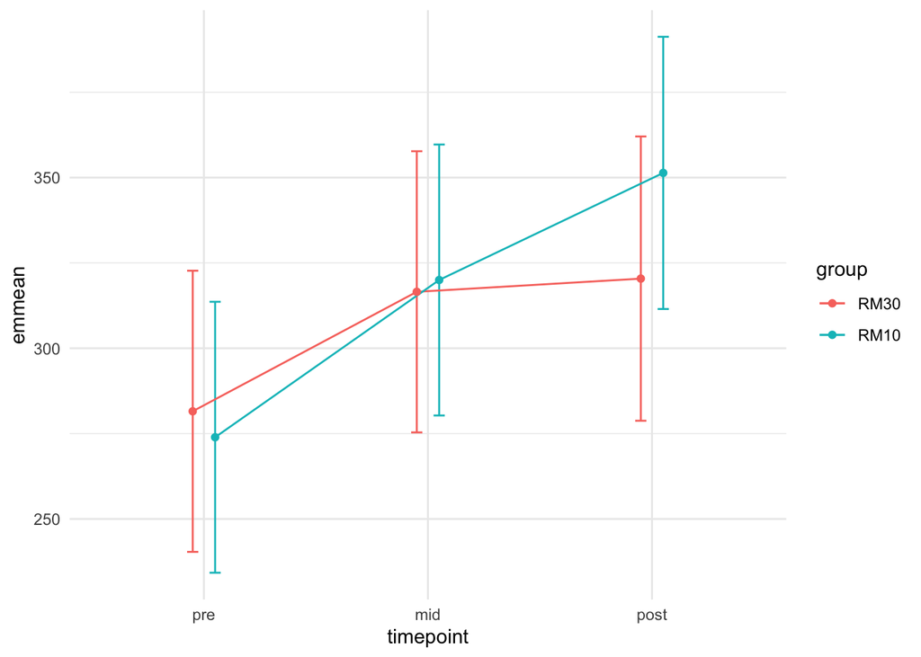

Figur1. Gjennomsnitt pr gruppe (med konfidensintervall)

Her ser vi gjennomsnittet for gruppe 10 RM og 30 RM. Vi kan her se at gruppene har en relativt lik økning fra tidspunkt pre til mid, deretter øker gruppen med 10 RM mer enn 30RM gruppen fra mid til post test.

#### Individuelle resultater og gjennomsnitt med konfidensintervall

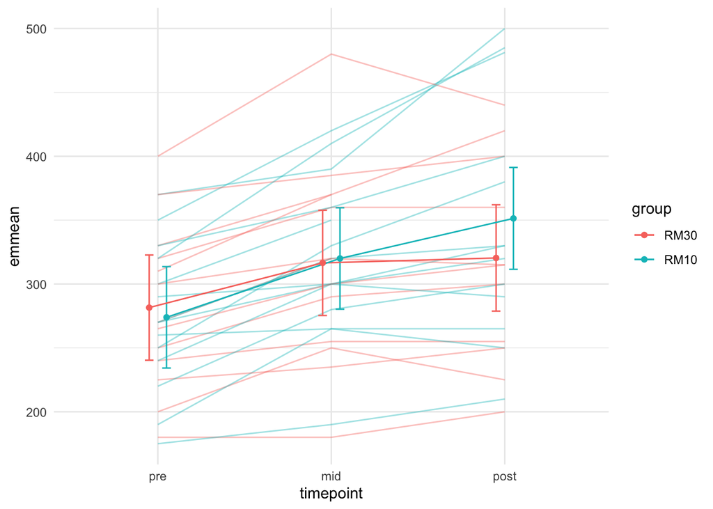

Figur 2. Individuelle resultater og gjennomsnitt (med konfidensintervall)

Figuren viser figur 1 sammen med linjene for hvert enkelt subjekt. Her ser vi at tendensene til gjennomsnittet følger tendensen for gruppen.

#### Inferens omkring 10 vs 30 reps, gjennomsnitt pr gruppe.

|  | Estimate | Std. Error | df | t value | Pr(>\|t\|) | X2.5.. | X97.5.. |
| --- | --- | --- | --- | --- | --- | --- | --- |
| (Intercept) | 281.53846 | 20.120706 | 28.56366 | 13.9924743 | 0.0000000 | 242.37410 | 320.70282 |
| timepointmid | 35.00000 | 8.968506 | 47.07854 | 3.9025454 | 0.0003018 | 17.80241 | 52.19759 |
| timepointpost | 38.86796 | 9.550460 | 47.27238 | 4.0697470 | 0.0001776 | 20.53927 | 57.16481 |
| groupRM10 | -7.60989 | 27.942231 | 28.56366 | -0.2723437 | 0.7873169 | -61.99862 | 46.77884 |
| timepointmid:groupRM10 | 11.07143 | 12.454834 | 47.07854 | 0.8889262 | 0.3785624 | -12.81138 | 34.95423 |
| timepointpost:groupRM10 | 38.57427 | 13.043542 | 47.22324 | 2.9573464 | 0.0048338 | 13.57176 | 63.59255 |

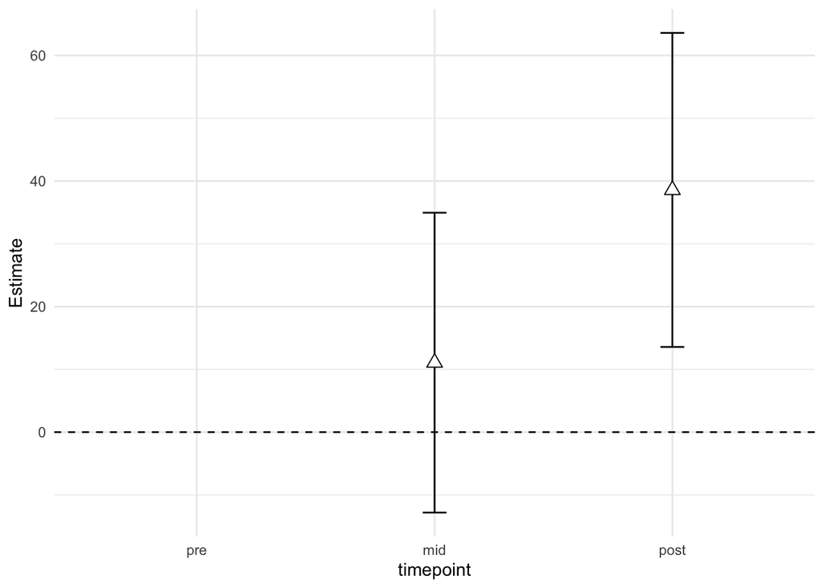

#### Oversikt figurer

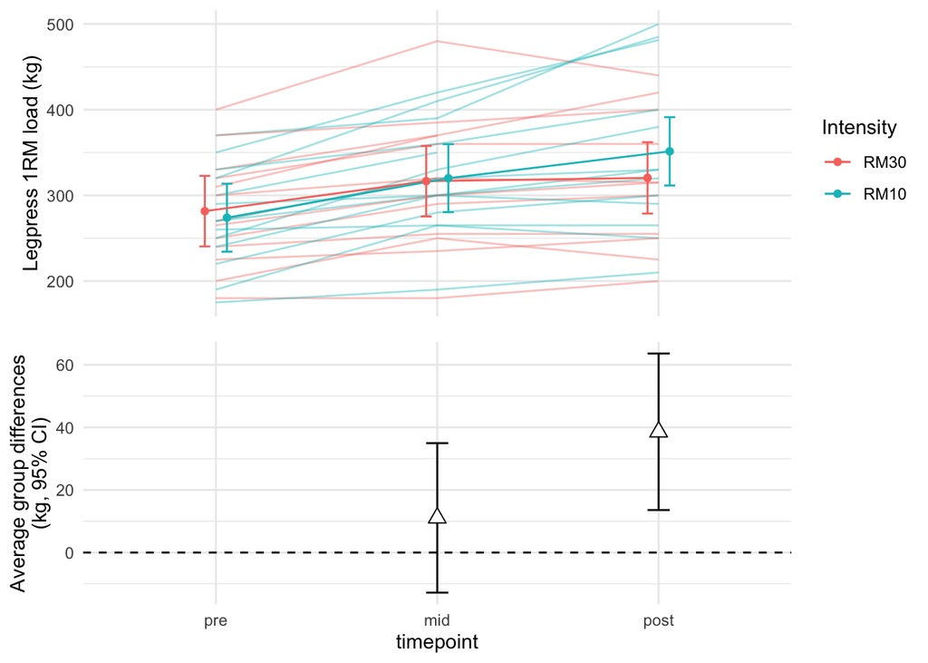

Figur 4. Samlet oversikt figurer

Figur 4.viser et sammendrag av figur 1,2 og 3.

#### Finnes det interaksjon mellom data?

```
## refitting model(s) with ML (instead of REML)
```

```
## Data: data
## Models:
## m0: load ~ timepoint + group + (1 | subject)
## m1: load ~ timepoint * group + (1 | subject)
##    npar    AIC    BIC  logLik deviance Chisq Df Pr(>Chisq)
## m0    6 813.37 827.51 -400.68   801.37
## m1    8 808.33 827.18 -396.16   792.33 9.039  2    0.01089 *
## ---
## Signif. codes:  0 '***' 0.001 '**' 0.01 '*' 0.05 '.' 0.1 ' ' 1
```

#### Tolkning tabell

Her ser vi en modell som sammenligner modellene m0 (inneholder ikke interaksjon) og m1 (inneholder interaksjon). Videre er det brukt Anova for å tolke dataene. I tabellen ser vi følgende: AIC er et mål på “beste fit”, her er en lav verdi bedre enn høy. LogLik er verdien testet i en Chi2 test og p-verdien indikerer om modellen varierer mer enn forventet av sampling error. Vi kan lese at sammenligningen av modeller at det er relativt usannsynlig å se denne forskjellen hvis modellene beskrev dataene likt. Det vil si at å legge til interaksjon mellom data øker m1s evne til å forklare dataene, og det er økt bevis for at det finnes interaksjonseffekt i dataene.

### Diskusjon

I metode og resultatdelen har vi nå sett på flere ulike figurer og plot for å sammenligne 10 reps med 30 reps. Figur 4 viser et sammendrag av modellene. Vi ser her en todelt figur som viser model estimate og estimerte gjennomsnittsforskjeller mellom 10 reps og 30 reps. Vi ser her at 10 reps gir bedre fremgang enn 30 reps. Dette er i overensstemmelse med tidligere forskning og teorien om at styrketrening på 25-30RM gir lavere muskelvekst enn feks 10 RM (Raastad et al.2010, 124) I figur 1. ser vi at forskjellen mellom gruppene ser ut til å være mindre mellom de to første testene enn mellom de to siste. Dette kan ha sammenheng med at i den første fasen av en treningsperiode vil nevrale adapsjoner ha en stor innvirkning på kraftutvikling. Dette vil være nervesystemet som lærer seg teknikk, koordinasjon av muskelgrupper og aktivering av motoriske enheter. Denne effekten vil avta, og deretter vil muskulens tverrsnitt stå for den største årsaken til økning i styrke (Raastad et al 2010, s. 64). Dette kan tenkes å være en mulig forklaring på denne forskjellen mellom testperiodene.

## DEL 2

I del 2 av oppgaven skl vi se på forskjellen i effekt på styrkeutvikling avhengig av om vi trener med ett eller tre sett. Raastad et al (2010, s 128) er det gjort forskning som viser god effekt med trening med ett sett, hvor man kan se at et relativt lite treningsvolum er tilstrekkelig for å se effekt av treningen. Men disse studiene er i stor grad gjort på utrente personer over relativt kort tid, og man kan derfor ikke se bort fra at en større del av styrkeutviklingen er relatert til nevrale adapsjoner (Raastad et al, 2010, s.64). Generelt ser det ut til at jo bedre trent en person er jo flere sett kreves for å øke muskelstyrke i beina, og 3-6 sett er vanlig å anbefale (Raastad et. al 2010, s.128-129) I denne delen av oppgaven skal vi bruke datasettet strengthtests.csv og se på spørsmålet "Hva burde det anbefalte volumet (ett eller tre sett) for styrkeutvikling være?

### Metode - statistiske analyser og resultater

Laste ned datasett og gjør klar data til plotting. Plotter data i figurer som vist under.

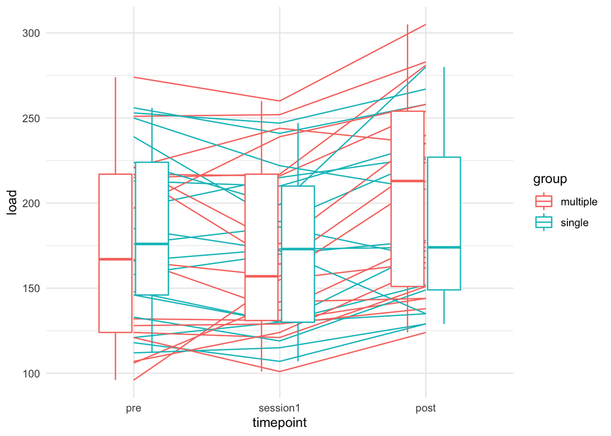

Figur 5. Individuelle resultater og grupperesultater multiple og single

```
## Linear mixed model fit by REML. t-tests use Satterthwaite's method [
## lmerModLmerTest]
## Formula: load ~ timepoint * group + (1 | subject)
##    Data: dat1
##
## REML criterion at convergence: 938.2
##
## Scaled residuals:
##      Min       1Q   Median       3Q      Max
## -2.20297 -0.49792  0.02869  0.43818  2.35138
##
## Random effects:
##  Groups   Name        Variance Std.Dev.
##  subject  (Intercept) 2462.6   49.62
##  Residual              288.1   16.97
## Number of obs: 102, groups:  subject, 34
##
## Fixed effects:
##                               Estimate Std. Error       df t value Pr(>|t|)
## (Intercept)                   174.1176    12.7204  36.8810  13.688 4.97e-16 ***
## timepointsession1               0.2941     5.8221  64.0000   0.051  0.95987
## timepointpost                  31.6471     5.8221  64.0000   5.436 9.10e-07 ***
## groupsingle                     7.9412    17.9893  36.8810   0.441  0.66147
## timepointsession1:groupsingle  -8.5294     8.2337  64.0000  -1.036  0.30414
## timepointpost:groupsingle     -24.1765     8.2337  64.0000  -2.936  0.00461 **
## ---
## Signif. codes:  0 '***' 0.001 '**' 0.01 '*' 0.05 '.' 0.1 ' ' 1
##
## Correlation of Fixed Effects:
##             (Intr) tmpnt1 tmpntp grpsng tmpn1:
## timpntsssn1 -0.229
## timepontpst -0.229  0.500
## groupsingle -0.707  0.162  0.162
## tmpntsssn1:  0.162 -0.707 -0.354 -0.229
## tmpntpst:gr  0.162 -0.354 -0.707 -0.229  0.500
```

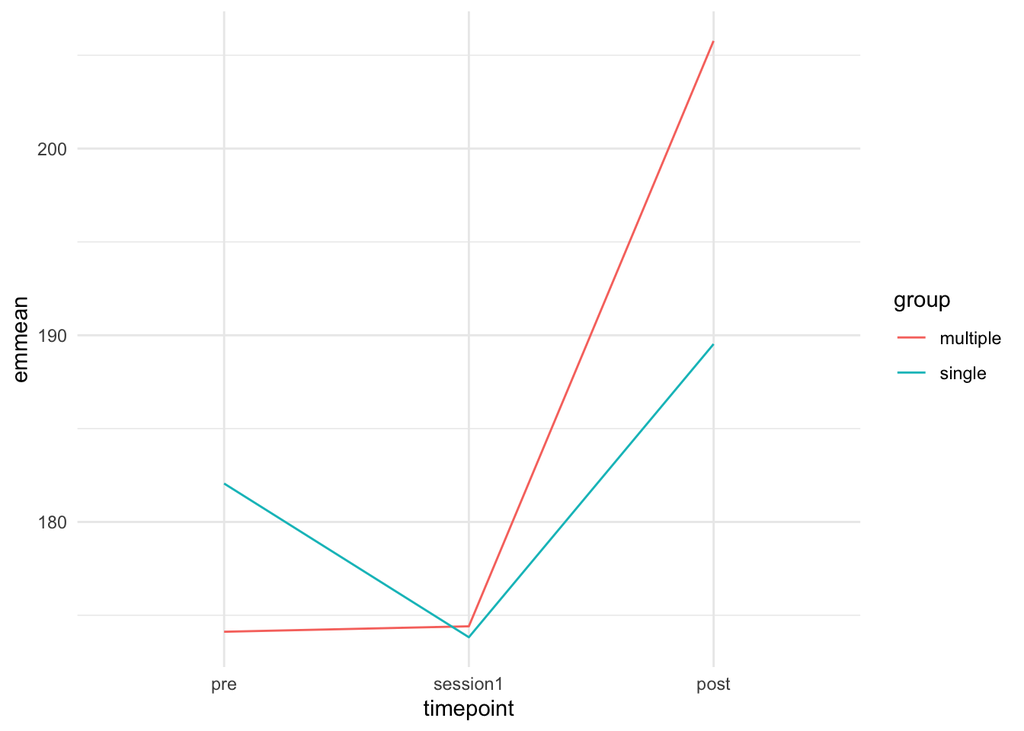

Figur.6. Gjennomsnittlig økning i styrke mellom tester

Som i figur 5 ser vi i figur 6. at forskjellen mellom gruppene ser ut til å øke ved tidspunkt post.

```
## Data: data
## Models:
## mod0: load ~ timepoint + group + (1 | subject)
## mod1: load ~ timepoint * group + (1 | subject)
##      npar    AIC    BIC  logLik deviance Chisq Df Pr(>Chisq)
## mod0    6 813.37 827.51 -400.68   801.37
## mod1    8 808.33 827.18 -396.16   792.33 9.039  2    0.01089 *
## ---
## Signif. codes:  0 '***' 0.001 '**' 0.01 '*' 0.05 '.' 0.1 ' ' 1
```

### Konklusjon

Resultatene viser at forskjellen mellom gruppene ikke er særlig stor mellom pre-test og session1. Deretter blir forskjellen større mellom gruppene mellom session1 og post-test. Dette kan ha sammenheng med at nevrale adapsjoner har større effekt i starten av en treningsperiode (Raastad et al 2010, s. 64), og det kan tenkes at dette kan gjøre at forskjellen blir større lenger ut i treningsintervensjonen. Raastad et al (2010,s.128-129) forteller også at 3-6 er vanlig anbefaling for trente personer når det kommer styrketrening bein. Resultatene ser ut til å støtte denne påstanden da effekten med 3 sett ser ut til å være større enn med ett sett over tid.

### Vedlegg

Oversikt over koder i R

```r
library(tidyverse)
library(readxl)
library(lme4)
library(emmeans)
library(pbkrtest)
library(lmerTest)
library(kableExtra)
library(cowplot)
```

#### Laste inn data

```r
#Her plasserer vi også tidsvariabler riktig for plotting, og ordner grupperinger slik at 30 RM kommer først.
data <- read_excel("ten_vs_thirty.xlsx", na = "NA") %>%
  filter(exercise == "legpress") %>%
  mutate(timepoint = factor(timepoint, levels = c("pre", "mid", "post")),
         group = factor(group,  levels = c("RM30", "RM10"))) %>%
  print()
```

```r
#Lage modellestimat
#  lmer funksjonen fra lme4 pakken
m1 <- lmer(load ~ timepoint * group + (1|subject), data = data)

#Residual plot
plot(m1)
#Model estimat
est <- emmeans(m1, specs = ~ timepoint|group)
```

#### Gjennomsnitt pr gruppe med konfidensintervall

```r
est %>%
  data.frame() %>%
  mutate(timepoint = factor(timepoint, levels = c("pre", "mid", "post"))) %>%

  ggplot(aes(timepoint, emmean, group = group, color = group)) +

  geom_errorbar(aes(ymin = lower.CL, ymax = upper.CL),
                position = position_dodge(width = 0.2),
                width = 0.1) +
  geom_line(position = position_dodge(width = 0.2)) +
  geom_point(position = position_dodge(width = 0.2)) +

  theme_minimal()
```

#### Individuelle resultater og gjennomsnitt med konfidensintervall

```r
est %>%
  data.frame() %>%
  mutate(timepoint = factor(timepoint, levels = c("pre", "mid", "post"))) %>%

  ggplot(aes(timepoint, emmean, group = group, color = group) ) +

  # Adds raw data
  geom_line(data = data, aes(timepoint, load, group = subject, color = group),
            # Add transparency to individual lines
            alpha = 0.4) +

  geom_errorbar(aes(ymin = lower.CL, ymax = upper.CL),
                position = position_dodge(width = 0.2),
                width = 0.1) +
  geom_line(position = position_dodge(width = 0.2)) +
  geom_point(position = position_dodge(width = 0.2)) +
  theme_minimal()
```

#### Inferens omkring 10 vs 30 reps, gjennomsnitt pr gruppe.

```r
# Lagre konfidensintervall
conf_intervals <- confint(m1)
```

```r
# Lagre regresjonskoeffisienter
coefs <- summary(m1)$coef

# Bruke cbind (column bind) for å kombinere tabellene over
coef_summary <- cbind(coefs, data.frame(conf_intervals)[3:8, ])

# Printe tabell

coef_summary %>%
  kable()
```

```r
coef_summary %>%
  mutate(coef = rownames(.)) %>%
  # filtrere interaksjonvariabler
  filter(coef %in% c("timepointmid:groupRM10", "timepointpost:groupRM10")) %>%
  # Lage "timepoint" variabel for å representere "data" data sett
  mutate(timepoint = gsub("timepoint", "", coef),
         timepoint = gsub(":groupRM10", "", timepoint)) %>%
  #  legge til rad så timepoint = pre er representert
  add_row(timepoint = "pre", coef = "pre") %>%
  # Endre rekkefølge tidspunkt
  mutate(timepoint = factor(timepoint, levels = c("pre", "mid", "post"))) %>%

  # Plotte
  ggplot(aes(timepoint, Estimate)) +


  # Lage 0- linje geom_hline (horisontal linje)
  geom_hline(yintercept = 0, lty = 2) +

  geom_errorbar(aes(ymin = X2.5.., ymax = X97.5..), width = 0.1) +
  geom_point(shape = 24, size = 3, fill = "white") +
  theme_minimal()
```

#### figurer del 1

```r
## Figur 1: Estimerer gjennomsnitt og raw data

figA <- est %>%
  data.frame() %>%
  mutate(timepoint = factor(timepoint, levels = c("pre", "mid", "post"))) %>%

  ggplot(aes(timepoint, emmean, group = group, color = group) ) +

  # Legger til raw data
  geom_line(data = data, aes(timepoint, load, group = subject, color = group),
            # legger til gjennomsniktighet for linjer
            alpha = 0.4) +

  geom_errorbar(aes(ymin = lower.CL, ymax = upper.CL),
                position = position_dodge(width = 0.2),
                width = 0.1) +
  geom_line(position = position_dodge(width = 0.2)) +
  geom_point(position = position_dodge(width = 0.2)) +
  theme_minimal() +

  # Endrer titler
  labs(y = "Legpress 1RM load (kg)",
       color = "Intensity") +

  # Fjerner tekst og indikatorer på x- aksen siden disse kan bli representert i den andre plottingen.
  theme(axis.text.x = element_blank(),
        axis.title.x = element_blank())

# Figure B: Forskjeller mellom grupper ( 95% konfidensintervall)

figB <- coef_summary %>%
  mutate(coef = rownames(.)) %>%
  # Filtrerer  bare interaksjonsvariabler
  filter(coef %in% c("timepointmid:groupRM10", "timepointpost:groupRM10")) %>%
  # Lager  "timepoint" variabel for å representere "data" data set.
  mutate(timepoint = gsub("timepoint", "", coef),
         timepoint = gsub(":groupRM10", "", timepoint)) %>%
  # Legger til rad så "timepoint= pre er representert
  add_row(timepoint = "pre", coef = "pre") %>%
  # Endrer rekkefølge variabler
  mutate(timepoint = factor(timepoint, levels = c("pre", "mid", "post"))) %>%

  # Plotter
  ggplot(aes(timepoint, Estimate)) +


  # Legger til horisontal linje, 0-linje
  geom_hline(yintercept = 0, lty = 2) +

  geom_errorbar(aes(ymin = X2.5.., ymax = X97.5..), width = 0.1) +
  geom_point(shape = 24, size = 3, fill = "white") +
  theme_minimal() +

    # Endrer titler
  labs(y = "Average group differences\n(kg, 95% CI)",
       color = "Intensity")

# Legger til  cowplot til begge figurene i figur 1
library(cowplot)

# Plotter grid med figA og figB
plot_grid(figA, figB, ncol = 1,
          # Jevner ut linjer så x-akser matcher
          align = "v",

          axis = "lr")
```

```r
summary(m1)

#### Sammendrag figur 4. Sammendraget av tabellen viser at standardavviket gjennomsnittlig er 68,85kg pr gruppe.
```

#### Finnes det interaksjon mellom data?

```
## refitting model(s) with ML (instead of REML)
```

```
## Data: data
## Models:
## m0: load ~ timepoint + group + (1 | subject)
## m1: load ~ timepoint * group + (1 | subject)
##    npar    AIC    BIC  logLik deviance Chisq Df Pr(>Chisq)
## m0    6 813.37 827.51 -400.68   801.37
## m1    8 808.33 827.18 -396.16   792.33 9.039  2    0.01089 *
## ---
## Signif. codes:  0 '***' 0.001 '**' 0.01 '*' 0.05 '.' 0.1 ' ' 1
```

## DEL 2

### Metode - statistiske analyser og resultater

```r
#Laste ned datasett og gjør klar data til plotting. Plotter data i figurer som vist under.

dat1 <- read_csv("strengthTests.csv", na="NA") %>%
  filter(exercise == "isok.60") %>%
  mutate(timepoint = factor(timepoint, levels = c("pre", "session1", "post"))) %>% print()
```

```r
dat1 %>%
  ggplot(aes(timepoint, load, group = subject, color = group)) +
  geom_line() +
  geom_boxplot(aes(group = NULL), width = 0.5) +
  theme_minimal()
```

```r
lmer2 <- lmer(load ~ timepoint * group + (1|subject), data = dat1)
summary(lmer2)
```

```r
plot(lmer2) # Figuren viser fin spredning i resultatene og det ser ut til å være "lite feil" med dataene.
```

[output not shown]

```r
conf_intervals2 <- confint(lmer2)
```

```r
coefs2 <- summary(lmer2)$coef
coef_summary2 <- cbind(coefs2, data.frame(conf_intervals2)[3:8, ] )
```

```r
est1 <- emmeans(lmer2, specs = ~ timepoint|group)
est1 %>%
  data.frame() %>%
  mutate(timepoint = factor(timepoint, levels = c("pre", "session1", "post"))) %>%
  ggplot(aes(timepoint, emmean, group = group, color = group)) + geom_line() +
  theme_minimal()
```

```r
# Lage modell som ikke inneholder interaksjonen Fit a model not containing the interaction
mod0 <- lmer(load ~ timepoint + group + (1|subject), data = data)


# Lage modell som inneholder interaksjon
mod1<- lmer(load ~ timepoint * group + (1|subject), data = data)

# Sammenligne modeller ved å bruke anova  funksjonen

anova(mod0, mod1)
```